CS249 -- Spring 2017 -- D.S. Parker © 2017

# HW4 -- Diamonds

## Assignment Overview

The goal of this assignment is for you to develop models for the [**diamonds** dataset](http://docs.ggplot2.org/current/diamonds.html), which is included in the [ggplot2](http://ggplot2.org) package.

This is a very simple assignment: you are asked to build four models: LDA or QDA, simple Linear Regression, log-scaled Linear Regression, and Logistic Regression. You then just upload the formulas (R commands) you used to construct these models to CCLE.

### Step 0: build the numeric.diamonds dataset

This notebook includes commands for buiding a dataset called ``numeric.diamonds` that you are to use for this assignment.

The diamonds dataset has 3 categorical attributes (cut, color, clarity) that are **ordered**. *The `numeric.diamonds` dataset is a numeric version of the diamonds dataset in which all these categorical attributes are converted to integer codes.*

After doing this transformation for cut and clarity also, the result is an entirely numeric dataset called `numeric.diamonds`.

In addition to this notebook, we've provided another called `Diamonds.ipynb` for gaining intuition about the data by walking through some exploratory graphics. Many aspects of the dataset are displayed. You do not have to use this notebook, it is totally optional, but it is included since visualization can help.

### Step 1: build a training set and test set (as subsets of numeric.diamonds) -- using your UID

First, set the random number generator seed to your UID. Then generate a training set and test set using the following commands:

`MY_UID = 123456789`**########## you must enter your UCLA UID here !!!**`set.seed( MY_UID )`

```
   n = nrow( numeric.diamonds )
   sample.size = 0.75 * n   ###### Use 75% of the data for the training set
   training.row.ids = sample( (1:n), sample.size )

   my.training.set = numeric.diamonds[  training.row.ids, ]
   my.test.set     = numeric.diamonds[ -training.row.ids, ]   # set complement of training.set.ids
```

**Please use exactly these commands to construct your training set and test set. Also, use the training set to construct each model, and use the test set to compute the accuracy of each model. The grading program will re-compute your model and its accuracy using this method.**

### Step 2: compute accuracy of 4 Baseline Models about diamonds

### Step 2: build four models about diamonds

For the numeric.diamonds dataset you are to develop a notebook that builds four models in R:

1. a LDA or QDA classification model that predicts a diamond's **Cut**.
2. a linear regression model that predicts a diamond's **Price**.
3. a linear regression model that predicts a diamond's **log10(Price)**.
4. a logistic regression model that predicts whether a diamond's **Price is above $1500**.

As an example, you might produce these models:

1. `qda( cut ~ price + table + color + clarity, data=my.training.set )`
2. `lm( price ~ carat + x + y + z + clarity, data=my.training.set )`
3. `lm( log10(price) ~ table + log10(carat) + color, data=my.training.set )`
4. `glm( I(price>1500) ~ carat + table + clarity, data=my.training.set, family = binomial )`

As these examples show, details matter: **you must specify the complete formula for each model in detail, listing all variables included.**

Please choose attributes that produce the most accuracy models you can. More accurate models will get a higher score; see below.

### Step 3: generate a CSV file "HW4_output.csv" including your 4 models

If these were your four models, then to complete the assignment you would create a CSV file `HW4_output.csv` containing eight lines:

```
      33.333, qda( cut ~ .,           data=my.training.set )
      88.888, lm(  price ~ .,         data=my.training.set )
      77.777, lm(  log10(price) ~ .,  data=my.training.set )
      88.888, glm( I(price>1500) ~ ., data=my.training.set, family=binomial )
      44.444, qda( cut ~ price + table + color + clarity, data=my.training.set )
      99.999, lm( price ~ carat + x + y + z + clarity, data=my.training.set )
      99.999, lm( log10(price) ~ table + log10(carat) + color, data=my.training.set )
      99.999, glm( I(price>1500) ~ carat + table + clarity, data=my.training.set, family=binomial )
```

**Each line gives the accuracy of a model on `my.test.set`** as well as **the exact command you used to generate the model**. There is no length restriction on the lines.

### Step 4: upload your CSV file and notebook to CCLE

Finally, go to CCLE and upload:

- your output CSV file `HW4_output.csv`
- your notebook file `HW4_Diamonds.ipynb`

We are not planning to run any of the uploaded notebooks. However, your notebook should have the commands you used in developing your models --- in order to show your work. As announced, all assignment grading in this course will be automated, and the notebook is needed in order to check results of the grading program.

## Rules -- building accurate models

### All evaluation of your models' accuracy will be done using your Training and Test data.

As mentioned above, everyone will generate their own Training set and Test set **after setting the random number seed to their UID**. The measure of accuracy will be determined by your Test set.

As a result, in this assignment everyone has their own accuracy objective function, defined by their UID.

Also: if you do not set the seed with your UID, your accuracy measures will differ from the ones produced by the grading program.

### Models must be constructed using the functions lda(), qda(), lm(), and glm()

You must use the `lm`, `glm`, `lda` and `qda` functions to compute your models. Both `lda()` and `qda()` are in the `MASS` package.) To produce a logistic regression model, you must include the option `family=binomial`, or equivalently `family=binomial("logit")`.

However, you have complete control over which variables are used in your model, and over which transformations you apply to the variables. So many different models are possible.

### The grading will compare your model's accuracy against a baseline model, using your data

The grading program will use these baseline models:

```
      qda( cut ~ .,           data=my.training.set )
      lm(  price ~ .,         data=my.training.set )
      lm(  log10(price) ~ .,  data=my.training.set )
      glm( I(price>1500) ~ ., data=my.training.set, family=binomial )
```

For each of the four baseline models, you must do two things:

1. (17 points): compute the accuracy of the baseline model.
2. (8 points): find a model that has higher accuracy than the baseline model.

It is not difficult to get 4 * 17 = 68 points on this assignment. However, 4 models that are better than the baseline will give 4 * 25 = 100 points.

# Generation of the numeric.diamonds Dataset

## Use this transformed dataset for building all Models in this assignment

```r
# we need the ggplot2 package to get the "diamonds" dataset

not.installed <- function(pkg) !is.element(pkg, installed.packages()[,1])

if (not.installed("ggplot2")) install.packages("ggplot2")
library(ggplot2)

if (not.installed("ggbiplot")) install.packages("ggbiplot")
library(ggbiplot)
```

```r
data(diamonds, package="ggplot2")

summary(diamonds)
```

```
     carat               cut        color        clarity          depth
 Min.   :0.2000   Fair     : 1610   D: 6775   SI1    :13065   Min.   :43.00
 1st Qu.:0.4000   Good     : 4906   E: 9797   VS2    :12258   1st Qu.:61.00
 Median :0.7000   Very Good:12082   F: 9542   SI2    : 9194   Median :61.80
 Mean   :0.7979   Premium  :13791   G:11292   VS1    : 8171   Mean   :61.75
 3rd Qu.:1.0400   Ideal    :21551   H: 8304   VVS2   : 5066   3rd Qu.:62.50
 Max.   :5.0100                     I: 5422   VVS1   : 3655   Max.   :79.00
                                    J: 2808   (Other): 2531
     table           price             x                y
 Min.   :43.00   Min.   :  326   Min.   : 0.000   Min.   : 0.000
 1st Qu.:56.00   1st Qu.:  950   1st Qu.: 4.710   1st Qu.: 4.720
 Median :57.00   Median : 2401   Median : 5.700   Median : 5.710
 Mean   :57.46   Mean   : 3933   Mean   : 5.731   Mean   : 5.735
 3rd Qu.:59.00   3rd Qu.: 5324   3rd Qu.: 6.540   3rd Qu.: 6.540
 Max.   :95.00   Max.   :18823   Max.   :10.740   Max.   :58.900

       z
 Min.   : 0.000
 1st Qu.: 2.910
 Median : 3.530
 Mean   : 3.539
 3rd Qu.: 4.040
 Max.   :31.800
```

The dataset has the following columns:

[output not shown]

Caution: the datset has skewed distributions. Please check below.

```r
dim(diamonds)  # not a tiny dataset
```

1. 53940

2. 10

```r
# low_prices = subset( diamonds$price, diamonds$price<5000 )

# hist( low_prices, breaks=200, col="green",
#      main = "diamond prices below $5000; notice the odd gap around 1500")
```

```r
# log-scaling the prices makes patterns clearer

# hist( log10(diamonds$price), breaks=50, col="skyblue",
#      main="distribution of log10(price) looks like a mixture" )

# plot(sort(log10(diamonds$price)), pch=".", col="skyblue")
```

## Basic cleaning of the data

```r
diamonds = subset( diamonds, (x>0) & (y>0) & (z>0) )  #  There are actually some zero values, we omit them.
```

### Prepare numeric encodings of "ordered categorical" values for Cut, Color, and Clarity

```r
colnames(diamonds)
```

1. 'carat'

2. 'cut'

3. 'color'

4. 'clarity'

5. 'depth'

6. 'table'

7. 'price'

8. 'x'

9. 'y'

10. 'z'

```r
( colors = levels(diamonds$color) )
```

1. 'D'

2. 'E'

3. 'F'

4. 'G'

5. 'H'

6. 'I'

7. 'J'

```r
## The levels of Colors should have the reverse ordering
##  { D > E > F > G > H > I > J }
##  (J is worst, D is best)

( levels(diamonds$color) = rev(colors) )
```

1. 'J'

2. 'I'

3. 'H'

4. 'G'

5. 'F'

6. 'E'

7. 'D'

```r
( cuts = levels(diamonds$cut) )
```

1. 'Fair'

2. 'Good'

3. 'Very Good'

4. 'Premium'

5. 'Ideal'

```r
## The levels of Cuts have the correct ordering
```

```r
( clarities = levels(diamonds$clarity) )
```

1. 'I1'

2. 'SI2'

3. 'SI1'

4. 'VS2'

5. 'VS1'

6. 'VVS2'

7. 'VVS1'

8. 'IF'

```r
## The levels of Clarity have ordering
##  { I1 < SI2 < SI1 < VS2 < VS1 < VVS2 < VVS1 < IF }
##  (I1 is worst, IF is best)

# ( levels(diamonds$clarity) = clarities[c(1:8)] )
#  the factor levels of 'clarity' match the real ordering.
```

### Convert the categorical values to integers -- using the unclass() function.

```r
numeric.diamonds = transform( diamonds,
                              cut = as.numeric(unclass(diamonds$cut)),
                              color = as.numeric(unclass(diamonds$color)),
                              clarity = as.numeric(unclass(diamonds$clarity))
                   )
```

```r
levels(diamonds$cut)
table( diamonds$cut, numeric.diamonds$cut )
```

1. 'Fair'

2. 'Good'

3. 'Very Good'

4. 'Premium'

5. 'Ideal'

```
                1     2     3     4     5
  Fair       1609     0     0     0     0
  Good          0  4902     0     0     0
  Very Good     0     0 12081     0     0
  Premium       0     0     0 13780     0
  Ideal         0     0     0     0 21548
```

```r
levels(diamonds$color)
table( diamonds$color, numeric.diamonds$color )
```

1. 'J'

2. 'I'

3. 'H'

4. 'G'

5. 'F'

6. 'E'

7. 'D'

```
        1     2     3     4     5     6     7
  J  6774     0     0     0     0     0     0
  I     0  9797     0     0     0     0     0
  H     0     0  9538     0     0     0     0
  G     0     0     0 11284     0     0     0
  F     0     0     0     0  8298     0     0
  E     0     0     0     0     0  5421     0
  D     0     0     0     0     0     0  2808
```

```r
levels(diamonds$clarity)
table( diamonds$clarity, numeric.diamonds$clarity )
```

1. 'I1'

2. 'SI2'

3. 'SI1'

4. 'VS2'

5. 'VS1'

6. 'VVS2'

7. 'VVS1'

8. 'IF'

```
           1     2     3     4     5     6     7     8
  I1     738     0     0     0     0     0     0     0
  SI2      0  9185     0     0     0     0     0     0
  SI1      0     0 13063     0     0     0     0     0
  VS2      0     0     0 12254     0     0     0     0
  VS1      0     0     0     0  8170     0     0     0
  VVS2     0     0     0     0     0  5066     0     0
  VVS1     0     0     0     0     0     0  3654     0
  IF       0     0     0     0     0     0     0  1790
```

### Inspect correlations among the Numeric Diamonds variables, as a check

```r
diamonds.correlation.matrix = cor( numeric.diamonds )

round( diamonds.correlation.matrix, 2 )
```

|  | carat | cut | color | clarity | depth | table | price | x | y | z |
| --- | --- | --- | --- | --- | --- | --- | --- | --- | --- | --- |
| carat | 1.00 | -0.13 | 0.29 | -0.35 | 0.03 | 0.18 | 0.92 | 0.98 | 0.95 | 0.96 |
| cut | -0.13 | 1.00 | -0.02 | 0.19 | -0.22 | -0.43 | -0.05 | -0.13 | -0.12 | -0.15 |
| color | 0.29 | -0.02 | 1.00 | 0.03 | 0.05 | 0.03 | 0.17 | 0.27 | 0.26 | 0.27 |
| clarity | -0.35 | 0.19 | 0.03 | 1.00 | -0.07 | -0.16 | -0.15 | -0.37 | -0.36 | -0.37 |
| depth | 0.03 | -0.22 | 0.05 | -0.07 | 1.00 | -0.30 | -0.01 | -0.03 | -0.03 | 0.10 |
| table | 0.18 | -0.43 | 0.03 | -0.16 | -0.30 | 1.00 | 0.13 | 0.20 | 0.18 | 0.15 |
| price | 0.92 | -0.05 | 0.17 | -0.15 | -0.01 | 0.13 | 1.00 | 0.89 | 0.87 | 0.87 |
| x | 0.98 | -0.13 | 0.27 | -0.37 | -0.03 | 0.20 | 0.89 | 1.00 | 0.97 | 0.98 |
| y | 0.95 | -0.12 | 0.26 | -0.36 | -0.03 | 0.18 | 0.87 | 0.97 | 1.00 | 0.96 |
| z | 0.96 | -0.15 | 0.27 | -0.37 | 0.10 | 0.15 | 0.87 | 0.98 | 0.96 | 1.00 |

```r
# Quick PCA of a sample of the data, to see if everything looks OK

n = nrow(numeric.diamonds)
sample.size = 2000

sample.row.ids = sample( (1:n), sample.size )

numeric.diamonds.sample = numeric.diamonds[sample.row.ids, ]

diamonds.sample = diamonds[sample.row.ids, ]
```

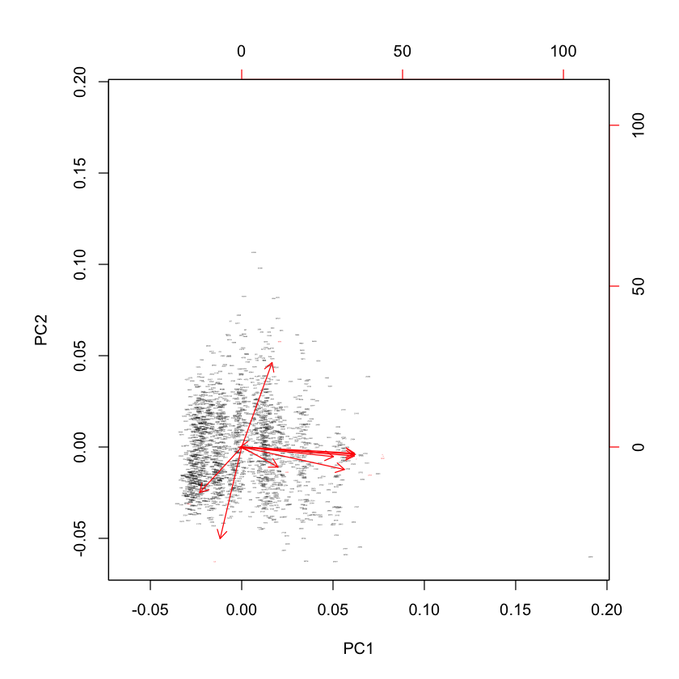

```r
numeric.diamonds.pca = prcomp(numeric.diamonds.sample, scale.=TRUE)
## biplot( numeric.diamonds.pca, xlabs=rep(".",sample.size) )

# ggbiplot( numeric.diamonds.pca, var.scale = 1,
 #         groups = diamonds$cut[sample.row.ids], ellipse = TRUE ) +
 #         labs(title = "Diamonds dataset:  principal components biplot, colored by cut")
biplot(numeric.diamonds.pca, cex=0.1)

# More visualization examples are in the notebook  Diamonds.ipynb
```

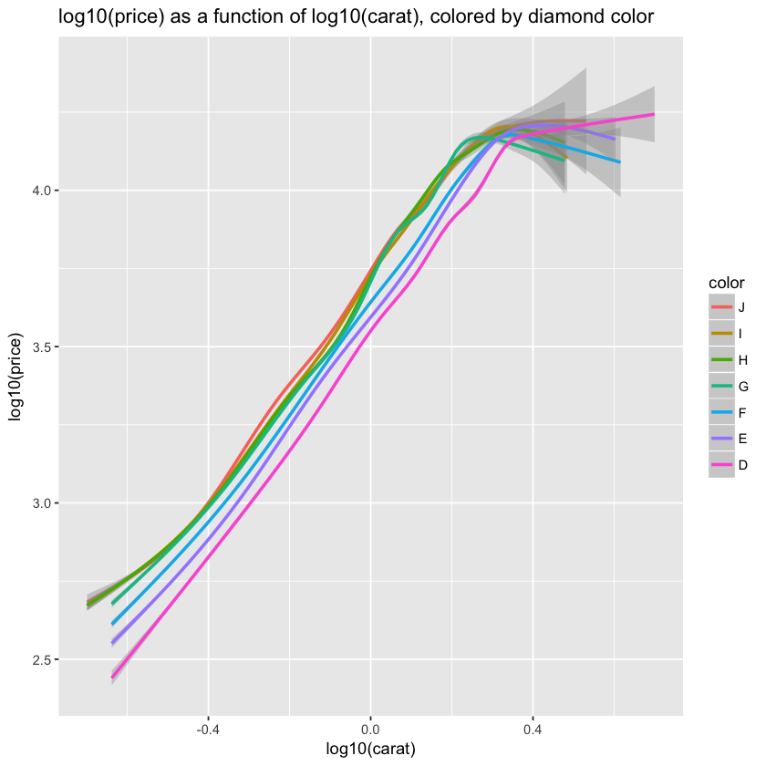

```r
ggplot(data=diamonds, aes(x=log10(carat), y=log10(price), color=color)) + geom_smooth() +
     ggtitle( "log10(price) as a function of log10(carat), colored by diamond color")
```

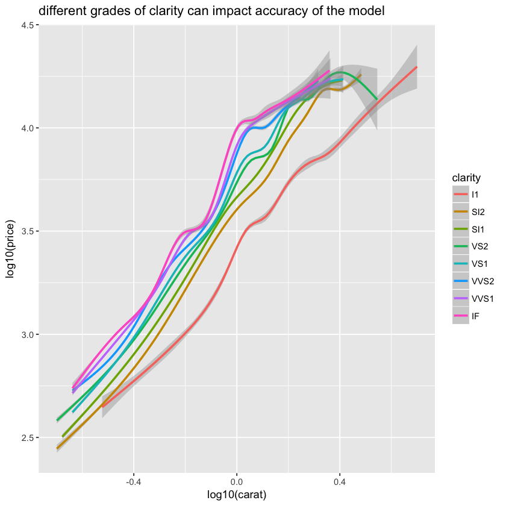

```r
ggplot(data=diamonds, aes(x=log10(carat), y=log10(price), color=clarity)) +
     geom_smooth() +
     ggtitle( "different grades of clarity can impact accuracy of the model")
```

```r
### another interesting plot, suggesting impacts on linearity by cut
# ggplot(data=diamonds, aes(x=log10(carat), y=log10(price), color=cut)) + geom_smooth() +
#     ggtitle( "log10(price) as a function of log10(carat), colored by cut")
```

# Step 1: generate your Training Set and Test Set from numeric.diamonds

```r
#  Please use exactly the following statements to generate these things:


set.seed( 123456789 ) ########## please enter your UCLA UID here !!!


n = nrow(numeric.diamonds)

training.sample.size = 0.75 * n  ###### Use 75% of the data for the training set

training.row.ids = sample( (1:n), training.sample.size )

my.training.set = numeric.diamonds[  training.row.ids, ]
my.test.set     = numeric.diamonds[ -training.row.ids, ]   # set complement of training.set.ids
```

# Step 2: compute Accuracy of the 4 Baseline Models on your Test Set

As mentioned above, there are 4 Baseline Models:

```
      qda( cut ~ .,           data=my.training.set )
      lm(  price ~ .,         data=my.training.set )
      lm(  log10(price) ~ .,  data=my.training.set )
      glm( I(price>1500) ~ ., data=my.training.set, family=binomial )
```

Develop procedures to compute their accuracy: one for classification models (like lda() and qda() in the MASS package), one for linear regression models (like lm()), and one for logistic regression models (like glm(family=binomial)).

Then: use your procedures to compute the accuracy of the Baseline Models on your Test Set.

# Step 2: build 4 Models improving on the Baseline Models

## Problem 1: a LDA or QDA classification model that predicts a diamond's Cut.

An example of a possible model is: `sample_m1 = qda( cut ~ price + table + color + clarity, data=my.training.set )`

If this model outperforms the first Baseline Model, you are done.

## Problem 2: a linear regression model that predicts Price.

An example of a possible model is: `sample_m2 = lm( price ~ carat + x + y + z + clarity, data=my.training.set )`

## Problem 3: a linear regression model that predicts log10(Price).

An example of a possible model is: `sample_m3 = lm( log10(price) ~ table + log10(carat) + color, data=my.training.set )`

## Problem 4: a logistic regression model that predicts whether Price is above $1500.

An example of a possible model is: `sample_m4 = glm( I(price>1500) ~ carat + table + clarity, data=my.training.set, family = binomial )`

Notice that the values of `I(price>1500)` are always 0 or 1. This model's predictions will be **0** if the price is below $1500, and **1** if the price is above $1500, so the resulting values are "binomial".

The dataset includes information on about 50 thousand diamonds. About 20 thousand have a price below $1500; and the others have a price above.

Thus a model that always simply predicts prices above $1500 might be right about 60% of the time. Your job is to do better than this baseline rate.

# Step 3: generate a CSV file "HW4_output.csv" including your model results

If these were your four models, then to complete the assignment you would create a CSV file `HW4_output.csv` containing eight lines:

```
      33.333, qda( cut ~ .,           data=my.training.set )
      88.888, lm(  price ~ .,         data=my.training.set )
      77.777, lm(  log10(price) ~ .,  data=my.training.set )
      88.888, glm( I(price>1500) ~ ., data=my.training.set, family=binomial )
      44.444, qda( cut ~ price + table + color + clarity, data=my.training.set )
      99.999, lm( price ~ carat + x + y + z + clarity, data=my.training.set )
      99.999, lm( log10(price) ~ table + log10(carat) + color, data=my.training.set )
      99.999, glm( I(price>1500) ~ carat + table + clarity, data=my.training.set, family=binomial )
```

Each line gives **the accuracy of a model on `my.test.set`**, and also **the exact command you used to generate your model**. The first four lines are for the baseline models. The second four lines are your improvements.

There is no length restriction on the lines; they can be as long as you want. These examples above are just examples, and they may not improve on the Baseline Models.

# Step 4: upload your CSV file and notebook to CCLE

Upload the files HW4_output.csv and your Jupyter notebook.

# Background Material

## R Formulas, Models, and the General Linear Model:

Chapter 11 of the [R Introduction Manual](https://cran.r-project.org/doc/manuals/R-intro.pdf) gives a good description of formulas, models, model updating (exploring alternative models), and the GLM.

### R formulas:

Sections 11.1 in Chapter 11 of the [R Introduction Manual](https://cran.r-project.org/doc/manuals/R-intro.pdf) hs a good description of formulas. A few constructs are important for this assignment:

- **Including an Intercept**:  
  `y ~ x`  
  `y ~ x + 1`  
  `y ~ 1 + x`  
  An intercept is included by default, so all of these formulas correspond to the same simple linear regression model of `y` on `x`.
- **Omitting the Intercept**:  
  `y ~ x - 1`  
  `y ~ x + 0`  
  `y ~ 0 + x`  
  `y ~ -1 + x`  
  These formulas are all equivalent, and correspond to the linear regression of `y` on `x` without an intercept.
- **Log-transformed Variables**:  
  `log(y) ~ x`  
  Regression on `x` of the transformed variable `log(y)` (with an implicit intercept term).
- **Integer Powers of a Variable**:  
  `y ~ x^2`  
  `y ~ 1 + x + I(x^2)`  
  `y ~ poly(x,2)`  
  regression of y on a quadratic polynomial of x. The first two formulas are equivalent -- the power `x^2` implicitly includes the powers below it. The third formula looks very similar, but is not completely equivalent: it uses "orthogonal" polynomials (with no interaction between each other), while the first two formulas use explicit powers, and interactions between them are considered.  
  Note that the expression `I(x^2)` represents an "insulated" new variable whose values are squares of values of `x`.

### Functions on R models:

Sections 11.3 in Chapter 11 of the [R Introduction Manual](https://cran.r-project.org/doc/manuals/R-intro.pdf) also gives a good description of functions on models that one can use:

- **coef**(model)  
  Extract the regression coefficient (matrix). Long form: coefficients(object).
- **formula**(model)  
  Extract the model formula.
- **plot**(model)  
  Produce four plots, showing residuals, fitted values and some diagnostics.
- **predict**(model, newdata=data.frame)  
  The data frame supplied must have variables specified with the same labels as the original. The value is a vector or matrix of predicted values corresponding to the determining variable values in data.frame.
- **residuals**(model)  
  Extract the (matrix of) residuals, weighted as appropriate.
- **step**(model)  
  Select a suitable model by adding or dropping terms and preserving hierarchies. The model with the smallest value of AIC (Akaike’s An Information Criterion) discovered in the stepwise search is returned.
- **summary**(model)  
  Print a comprehensive summary of the results of the regression analysis.
- **vcov**(model)  
  Returns the variance-covariance matrix of the main parameters of a fitted model object.

### The General Linear Model:

Sections 11.6 in Chapter 11 of the [R Introduction Manual](https://cran.r-project.org/doc/manuals/R-intro.pdf) includes a tutorial on the GLM, and options for the glm() function.

Relevant for this assignment:

- `glm(x ~ y, family = gaussian )` is equivalent to the usual linear regression model `lm( x ~ y )`
- `glm(x ~ y, family = gaussian("log") )` is equivalent to the log-linear model `lm( log(x) ~ y )`
- `glm(x ~ y, family = binomial )` is the logistic regression model

# Example: Building a Model (simple supervised learning)

### This example, discussed in class, uses the MASS package for supervised learning of LDA models.

### Construct a training set and test set (from the Iris dataset)

```r
data(iris)

n = nrow(iris)

training.sample.size = floor( 0.75 * n )  ###### Use 75% of the data for the training set

iris.ids = (1:n)

training.set = sample( iris.ids, training.sample.size ) # Generate a random sample
test.set     = iris.ids[-training.set]       # The set complement of training.set

training.set
test.set
# table(iris$Species)                  # Tabulate the number of each species
# table(iris$Species[training.set])    # Tabulate species for the training set
# table(iris$Species[test.set])        # Tabulate species for the test set
```

1. 130

2. 91

3. 112

4. 1

5. 9

6. 38

7. 39

8. 105

9. 75

10. 114

11. 16

12. 40

13. 13

14. 116

15. 52

16. 42

17. 56

18. 81

19. 73

20. 72

21. 142

22. 138

23. 22

24. 5

25. 104

26. 131

27. 125

28. 46

29. 109

30. 86

31. 137

32. 124

33. 48

34. 67

35. 59

36. 144

37. 126

38. 128

39. 94

40. 62

41. 28

42. 2

43. 113

44. 93

45. 135

46. 53

47. 32

48. 139

49. 92

50. 24

51. 20

52. 21

53. 74

54. 133

55. 96

56. 87

57. 85

58. 78

59. 45

60. 69

61. 18

62. 41

63. 119

64. 148

65. 60

66. 12

67. 49

68. 4

69. 117

70. 141

71. 66

72. 132

73. 120

74. 71

75. 25

76. 89

77. 107

78. 140

79. 115

80. 50

81. 110

82. 68

83. 29

84. 14

85. 83

86. 98

87. 127

88. 82

89. 111

90. 103

91. 7

92. 33

93. 58

94. 102

95. 90

96. 27

97. 34

98. 17

99. 65

100. 97

101. 11

102. 99

103. 10

104. 31

105. 3

106. 145

107. 122

108. 57

109. 101

110. 70

111. 134

112. 8

1. 6

2. 15

3. 19

4. 23

5. 26

6. 30

7. 35

8. 36

9. 37

10. 43

11. 44

12. 47

13. 51

14. 54

15. 55

16. 61

17. 63

18. 64

19. 76

20. 77

21. 79

22. 80

23. 84

24. 88

25. 95

26. 100

27. 106

28. 108

29. 118

30. 121

31. 123

32. 129

33. 136

34. 143

35. 146

36. 147

37. 149

38. 150

### Constructing an LDA model

```r
if (!(is.element("MASS", installed.packages())))  install.packages("MASS")
library(MASS)

LDA.model = lda( Species ~ ., data = iris, subset = training.set )
LDA.model
```

```
Call:
lda(Species ~ ., data = iris, subset = training.set)

Prior probabilities of groups:
    setosa versicolor  virginica
 0.3392857  0.3214286  0.3392857

Group means:
           Sepal.Length Sepal.Width Petal.Length Petal.Width
setosa         4.978947    3.410526     1.468421   0.2421053
versicolor     5.888889    2.813889     4.236111   1.3305556
virginica      6.505263    2.963158     5.476316   2.0078947

Coefficients of linear discriminants:
                   LD1        LD2
Sepal.Length  0.870845  0.2391903
Sepal.Width   1.452269  1.8951132
Petal.Length -2.477253 -1.1918484
Petal.Width  -2.276150  3.1216930

Proportion of trace:
   LD1    LD2
0.9936 0.0064
```

```r
str( predict( LDA.model, subset = test.set, data = iris ))
```

```
List of 3
 $ class    : Factor w/ 3 levels "setosa","versicolor",..: 3 2 3 1 1 1 1 3 2 3 ...
 $ posterior: num [1:112, 1:3] 2.66e-34 1.49e-23 1.07e-37 1.00 1.00 ...
  ..- attr(*, "dimnames")=List of 2
  .. ..$ : chr [1:112] "130" "91" "112" "1" ...
  .. ..$ : chr [1:3] "setosa" "versicolor" "virginica"
 $ x        : num [1:112, 1:2] -4.96 -2.64 -5.53 8.03 6.55 ...
  ..- attr(*, "dimnames")=List of 2
  .. ..$ : chr [1:112] "130" "91" "112" "1" ...
  .. ..$ : chr [1:2] "LD1" "LD2"
```

### Simple accuracy calculation (for a classification model)

```r
predictions = predict( LDA.model, iris[test.set, 1:4] )
print(predictions$class)
incorrect.predictions  =  (predictions$class != iris$Species[test.set] )

incorrect.ids = test.set[incorrect.predictions]

# iris[ incorrect.ids , ]

confusion.matrix = table( iris$Species[test.set], predictions$class )
confusion.matrix

accuracy = (length(test.set) - length(incorrect.ids)) / length(test.set)
accuracy
```

```
 [1] setosa     setosa     setosa     setosa     setosa     setosa
 [7] setosa     setosa     setosa     setosa     setosa     setosa
[13] versicolor versicolor versicolor versicolor versicolor versicolor
[19] versicolor versicolor versicolor versicolor virginica  versicolor
[25] versicolor versicolor virginica  virginica  virginica  virginica
[31] virginica  virginica  virginica  virginica  virginica  virginica
[37] virginica  virginica
Levels: setosa versicolor virginica
```

```
             setosa versicolor virginica
  setosa         12          0         0
  versicolor      0         13         1
  virginica       0          0        12
```

0.973684210526316